# Printing tutorial

This tutorial illustrates how to use halftoning to achieve the visual illusion of gray-levels in a binary display system. You will learn about two approaches: thresholding approaches using dither patterns and the computational method called error diffusion.

When you examine the halftoned images, try squinting or viewing the image from a distance.

We first wrote this tutorial nearly 25 years ago. Since that time, printers include multiple ink densities and they control dot placement at very fine resolution. Hence, since about 2015 we haven't used this material much in class. We keep it around for historical interest.

## Contents

- Introduction - historical
- Halftoning
- Bayer dithering
- Bayer's optimum dot pattern
- Halftoning an image
- Error Diffusion
- Final comment
- PURPOSE: Image halftoning for binary, black/white, printers
- AUTHOR: R. Koehler, X. Zhang, B. Wandell
- DATE: 02.25.97
- CONCEPTS
- Matlab 7: Checked 01.08.06
- Matlab 5: Checked 01.06.98

## Introduction - historical

Historically, printers placed a binary mark at each spot on the page: that is, they either place a dot at position or not. Hence, unlike monitors, printers do not display a range of intensity levels.

To create the illusion of intensity variation, printers fool the eye by trading area for intensity. One way to do this is to divide the image into a number of small areas (halftone cells) and print more or less dots in this area according to a rule that is governed by the local image intensity. This halftoning process substitutes a number of dots for a variation in gray level (or color).

The algorithm for simple halftoning is to define a small pattern, defined over the halftone cell, that spans a small number of printable dots. The values within this halftone cell define a set of thresholds. The binary decision of whether to print or not at each addressable print location is governed by how the image intensity compares to the entry in the halftone cell. Halftone algorithms are often named by the principle that underlies the pattern within the halftone cell.

Let's begin with a simple halftone algorithm called "cluster dot." This algorithm uses a halftone cell in which the printed area has the shape of a larger and larger dot. As the image region within the halftone cell becomes darker and darker, the size of the dot grows larger. Here is an example of a 4x4 halftone cell that illustrates the idea.

## Halftoning

Building a halftone cell

```matlab
halfToneCell_4 = ...
		[15 5 12 14
		10 3 2 8
		7 1 4 11
		13 9 6 16];
```

Suppose we have a 4x4 image region that has a hight density, say 12.

```matlab
 im = 12*ones(4,4);
```

To print this section of the image, we compare the density in the image with the thresholds in the halftone cell,

```matlab
cmp = halfToneCell_4 < im
```

```
cmp =

  4×4 logical array

   0   1   0   0
   1   1   1   1
   1   1   1   1
   0   1   1   0
```

The locations set to one are printed with a black dot, and the locations with 0 are unprinted (white). Because of Matlab's ordering, we will add 1 to cmp and build the binary color mapas

```
bMap =

     1     1     1
     0     0     0
```

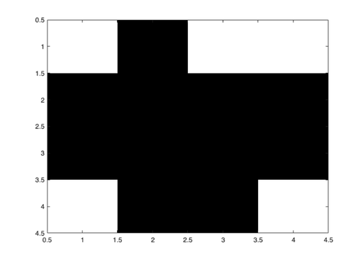

```matlab
bMap = [1 1 1; 0 0 0]
ieNewGraphWin;
colormap(bMap); image( cmp + 1 );
```

For this high density, we print most of the halftone cell as black. Now, let's see how the halftone cell would print at a set of increasing densities:

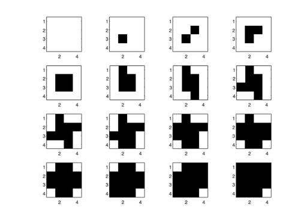

```matlab
cnt = 1;
for density = 1:16
  im = ones(4,4)*density;
  cmp = (halfToneCell_4 < im);
  subplot(4,4,cnt)
  image(cmp + 1); axis image
  cnt = cnt + 1;
end
```

As the mean image density varies from low (light) to high (dark) the region corresponding to the halftone cell is printed as an increasingly large black dot. Applying the Halftone cell Now we can apply the halftone cell to an entire test image. We start with a simple test image containingeight gray strips that vary from black to white.

```matlab
grayStrips = 8;
bw_range = [0, 1];
sweep_size = 128;

[x,y] = meshgrid(0:sweep_size-1, 0:sweep_size-1);
y = fix(y * grayStrips / sweep_size) / grayStrips;
x = x / (sweep_size * grayStrips);
sweep_8 = ones(sweep_size, sweep_size) - (x + y);
```

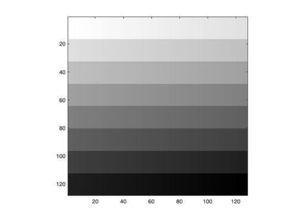

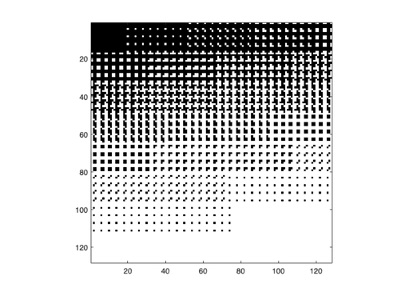

```matlab
ieNewGraphWin;
imagesc(sweep_8); axis image; axis equal; colormap(gray);
% Gamma correction
% The values in sweep_8 are frame buffer values that are nonlinearly related
% to intensity.  The halftoning principle depends on LINEAR SPATIAL AVERAGING
% of the dots.  Hence, to make the proper decisions about the halftoning, we have
% to take into account the true intensity associated with each level. Hence, before
% halftoning we need to convert the frame buffer values to linear gray scale values
% (gamma correction--review the ColorMatching tutorial for why and how to perform
% gamma correction). We use a gamma value = 2.

monitorGamma = 2;
sweep_8_linear = sweep_8 .^ monitorGamma;
HTsweep_4 = HalfToneImage(halfToneCell_4, sweep_8_linear);
ieNewGraphWin; imagesc(HTsweep_4); axis equal; axis image; colormap(bMap)
```

Were we doing this on a printer, rather than a display, we would have to know the relationship between the image density and the displayed intensity, and also, we would need to know the relationship between the image dot size in the cluster dot and the reflected intensity.

The image halftone is created in the routine HalfToneImage. (Use type HalfToneImage to see the full routine). The process simply applies the HalfToneCell comparison again and again across the image. The light image regions contain no black dot or a small black dot. The dark image regions contain large black dots or a complete black dot. To see the code for HalfToning:

type HalfToneImage.m

The halftone does a worse job tracking the gray levels if the halftone cell is smaller.

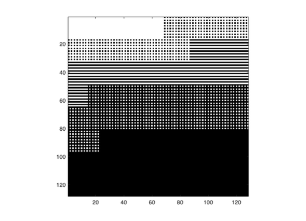

```matlab
halfToneCell_2 = [ 4 3; 2 1];
HTsweep_2 = HalfToneImage(halfToneCell_2, sweep_8_linear);
ieNewGraphWin; imagesc(HTsweep_2);colormap(gray); axis image
```

We can also scale up these two images to see how the halftones are formed.

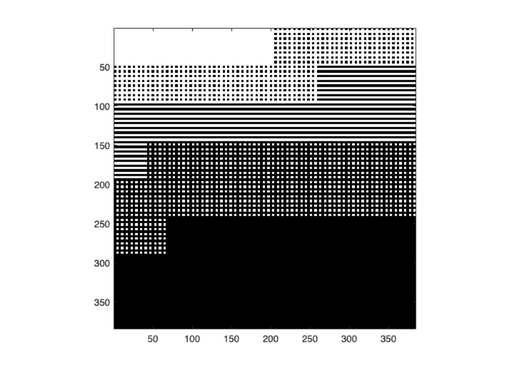

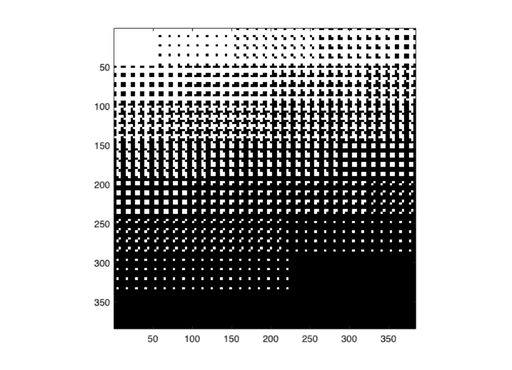

```matlab
scale_sweep_2 = kron(HTsweep_2, ones(3,3));
ieNewGraphWin; imagesc(scale_sweep_2); colormap(gray); axis image
scale_sweep_4 = kron(HTsweep_4, ones(3,3));
ieNewGraphWin; imagesc(scale_sweep_4); colormap(gray); axis image
```

## Bayer dithering

In the supplemental reading, Bayer describes a halftone cell for Figure 2: "imitation halftone pattern." We enter it as:

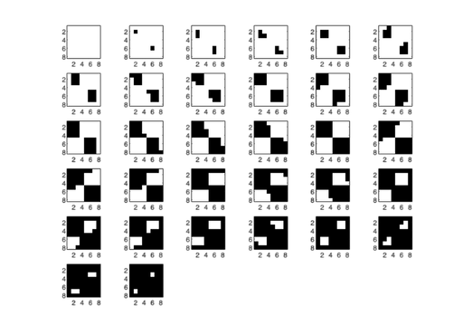

```matlab
halfToneCell_B2 = ...
		[7 6 5 16 17 18 19 20
		8 1 4 15 28 29 30 21
		9 2 3 14 27 32 31 22
		10 11 12 13 26 25 24 23
		17 18 19 20 7 6 5 16
		28 29 30 21 8 1 4 15
		27 32 31 22 9 2 3 14
		26 25 24 23 10 11 12 13];

ieNewGraphWin;
colormap(bMap)
cnt = 1;
for density = 1:32
  im = ones(8,8)*density;
  cmp = (halfToneCell_B2 < im);
  subplot(6,6,cnt);
  image(cmp + 1); axis image;
  cnt = cnt + 1;
end
```

This pattern is much like the simple cluster dot, except it introduces a smaller pair of dots oriented at 45 deg to the image. Now apply it to the sweep pattern:

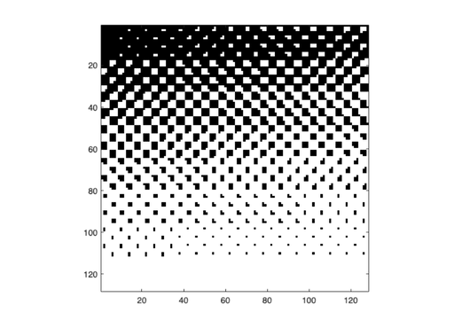

```matlab
clf
HTsweep_B2 = HalfToneImage(halfToneCell_B2, sweep_8_linear);
ieNewGraphWin; imagesc(HTsweep_B2); colormap(bMap); axis equal, axis image;
```

## Bayer's optimum dot pattern

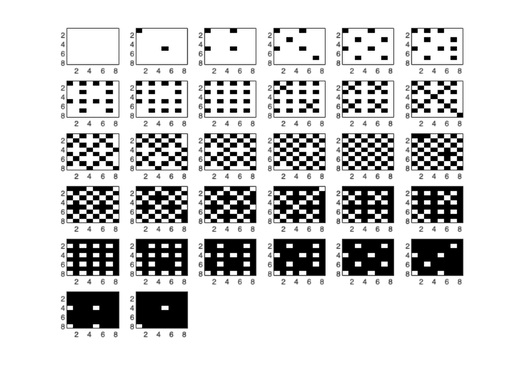

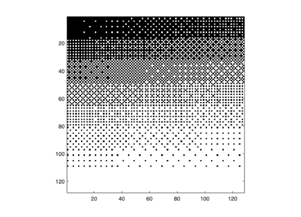

```matlab
halfToneCell_B4 = ...
		[1 17 5 21 2 18 6 22
		25 9 29 13 26 10 30 14
		7 23 3 19 8 24 4 20
		31 15 27 11 32 16 28 12
		2 18 6 22 1 17 5 21
		26 10 30 14 25 9 29 13
		8 24 4 20 7 23 3 19
		32 16 28 12 31 15 27 11];

ieNewGraphWin;
colormap(bMap)
cnt = 1;
for density = 1:32
  im = ones(8,8)*density;
  cmp = (halfToneCell_B4 < im);
  subplot(6,6,cnt); axis equal; axis image;
  image(cmp + 1);
  cnt = cnt + 1;
end
HTsweep_B4 = HalfToneImage(halfToneCell_B4, sweep_8_linear);
ieNewGraphWin; imagesc(HTsweep_B4); axis equal; axis image; colormap(bMap);
```

## Halftoning an image

These halftones can also be applied to a real image.

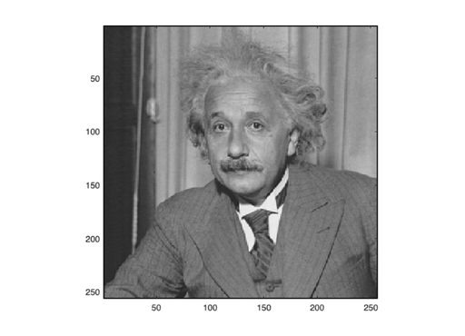

[figure not shown]

```matlab
D = load('jpegFiles/einstein.mat'); img = D.X;
img = img / 256;
ieNewGraphWin; imagesc(img);axis equal; axis image; colormap(gray);
% gamma correction
img_linear = img .^ monitorGamma;

HTimg_B4 = HalfToneImage(halfToneCell_B4, img_linear);
ieNewGraphWin; imagesc(HTimg_B4); colormap(gray)
axis equal; axis image
```

If you enlarge this image you should see that the halftone cells are not the same as the basic patterns we saw. This is because the halftone dot is formed by the space-varying image, not simple constant patterns. The image changes density rapidly over sapce and the dots reflect the correct image density.

[figure not shown]

```matlab
scale_img_B4 = kron(HTimg_B4, ones(3,3));
ieNewGraphWin; imagesc(scale_img_B4); colormap(gray)
axis equal; axis image
```

You can see this easily by changing the original sweep to a different number of strips, say 5. Thus the halftone cells will not line up on the strip boundaries.

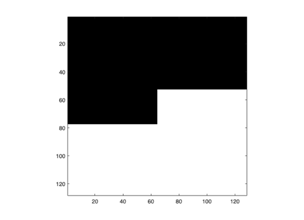

```matlab
grayStrips = 5;
[x,y] = meshgrid(0:sweep_size-1, 0:sweep_size-1);
y = fix(y * grayStrips / sweep_size) / grayStrips;
x = x/(sweep_size * grayStrips);
sweep_5 = ones(sweep_size, sweep_size) - (x + y);
ieNewGraphWin; imagesc(sweep_5); colormap(bMap)
axis equal; axis image
```

Now gamma correction

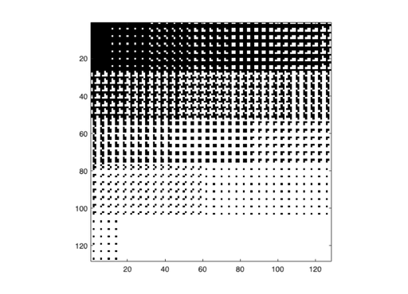

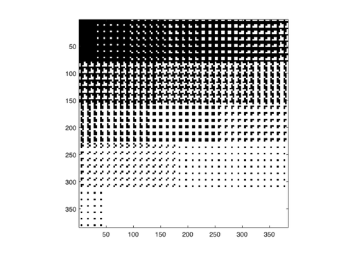

```matlab
sweep_5_linear = sweep_5 .^ monitorGamma;

HTsweep_5_4 = HalfToneImage(halfToneCell_4, sweep_5_linear);
ieNewGraphWin; imagesc(HTsweep_5_4); colormap(bMap)
axis equal; axis image
scale_sweep_5_4 = kron(HTsweep_5_4, ones(3,3));
ieNewGraphWin; imagesc(scale_sweep_5_4);colormap(bMap)
axis equal; axis image
```

## Error Diffusion

This version uses an algorithm by Floyd and Steinberg which is described in the course supplemental reading. The algorithm is called error diffusion, though it is sometimes called stochastic screening. Variations of the basic error diffusion pattern are used by Ulichney.

Unlike the halftone cells described in part 1, error diffusion does not use a fixed positioning for the halftone output. Rather, each pixel is compared to a threshold and a decision is made to print that pixel as black, or leave it white. The difference between the actual pixel density and the level printed is the error. That error is diffused to neighboring pixels (to the right and/or down) and the process is repeated.

We can use the same images as we did before to see the impact of this type of halftoning. Actually, this process is usually referred to as dithering. Screening is yet another term which includes both the halftoning described in tutorial part 1 and here. (Dithering can also refer to the halftoning previously described.)

As with the fixed position cells described before, the objective of error diffusion is to replace a set of intermediate level densities with a binary set whose area approximates the optical denisty (appearance) of the original.

The algorithm has one free set of parameters called the diffusion matrix, FS. This matrix determines how the error at a point is distributed to its neighbors. The pixel being considered is in the middle of the top row of FS. The fraction of the error to be applied to each neighbor is set by the value in FS. There is no standard way to deal with the errors that are accumulated at the end of each row: some peple just throw them away, others roll them down to the next row, others - who knows. Here, we will treat the image as if it were a spiral and roll the errors from each end "down and to the right" or "up and to the left." This is complicated in the algorithm so on't worry too much if the process is not entirely clear. Floyd Steinberg The simplest error diffusion is to just pass the error from each pixel to the neighbor to the right. We can do this with:

```matlab
FS_1 = [0 0 1];
```

You can view the implementation of the error diffusion by entering:

type FloydSteinberg.m

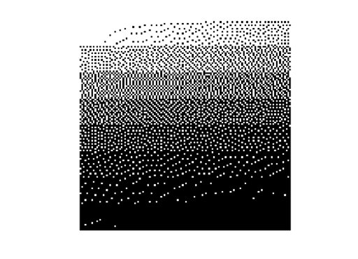

```matlab
HT_image_1 = FloydSteinberg(FS_1, sweep_8_linear);

ieNewGraphWin;
imagesc(sweep_8); colormap(gray)
imagesc(HT_image_1); colormap(gray);
% Rendering
% Now we can apply the matrix specified by in their paper.

FS_2 =	[0 0 0 7 5; ...
	3 5 7 5 3; ...
	1 3 5 3 1];
FS_2 = FS_2 / sum(FS_2(:));
HT_image_2 = FloydSteinberg(FS_2, sweep_8_linear);
imagesc(HT_image_2); colormap(gray)
% Ulichney rendered

FS_3 =	[0 0 7;  ...
	3 5 1];
FS_3 = FS_3 / sum(FS_3(:));
HT_image_3 = FloydSteinberg(FS_3, sweep_8_linear);
imagesc(HT_image_3); axis off; axis image
```

Finally, let's look at a real image

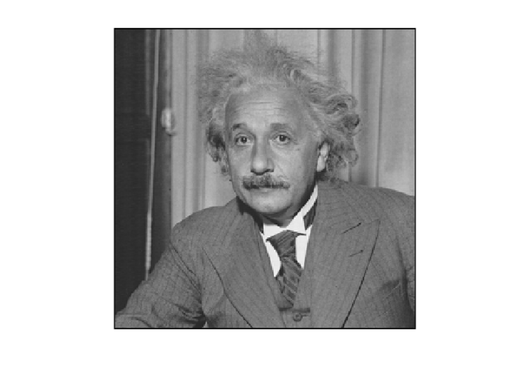

```matlab
D = load('jpegFiles/einstein.mat'); img = D.X;
img = img / 256;
imagesc(img); axis off; axis image
```

Corrected for gamma

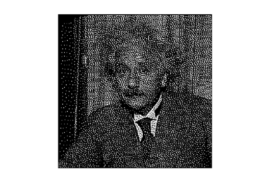

```matlab
img_linear = img .^ monitorGamma;
HTimg_2 = FloydSteinberg(FS_2, img_linear);
imagesc(HTimg_2); axis off; axis image
```

## Final comment

People's preference depends on the choice of output device. Specific printing technologies have different properties that make different halftoning algorithms look better or worse. Choosing a screening process can be quite difficult because methods of deciding on the preference between two images, neither of which is very good, is hard to specify. Worse yet, even when people do make consistent choices the choice they make can depend on the test image. Sigh.

[Published with MATLAB® R2025b](https://www.mathworks.com/products/matlab/)